# project pitch ideas

490300286

# summary

tried hierarchical clustering and k means clustering to see if there are any groupings in the amount of macronuntrients people eat. Both kmeans and hierarchical clustering results shown for 3 or 4 clusters which were found to be ideal.

If 3 clusters selected, it just splits into 3 groups which are high fat, high carb, high protein diet.

Optimal split was found with k = 4 using kmeans (rather than hierarchical) as this gives the most interpretable results.

```r
# selecting macros
macros = tech_nutr %>% select(ABSPID,
                              PROTT1,
                              PROTT2,
                              FATT1,
                              FATT2,
                              CHOWSAT1,
                              CHOWSAT2)


# gettin average of macros
macros$avg_protein <- rowMeans(macros[ , c(2,3)], na.rm=TRUE)
macros$avg_fat <- rowMeans(macros[ , c(4,5)], na.rm=TRUE)
macros$avg_carb <- rowMeans(macros[ , c(6,7)], na.rm=TRUE)

# making macros1 only df of averages
macros1 = macros %>% select(-c(2:7))



# this code below is useless, i tried doing PCA and clustering on total macros, but this is stupid because skinny people will eat less total compared to fat people. Next code chunk is more useful.

# pca
# res.pca <- prcomp(
#   macros_numeric,
#   center = T,
#   scale = T
# )
#
# summary(res.pca)
#
# # extracting pc1 and pc2
# pcs = res.pca$x[, c(1,2)]
#
# # kmeans on pc1 and pc2
# k <- kmeans(pcs, 2, nstart=25, iter.max=1000)
# kmeans_cluster = k$cluster %>% as.factor()
#
# pcs_kmeans = as.data.frame(cbind(pcs, kmeans_cluster))
# pcs_kmeans$kmeans_cluster = factor(pcs_kmeans$kmeans_cluster)
#
# ggplot(pcs_kmeans, aes(x = PC1, y = PC2)) +
#   geom_point(color = kmeans_cluster)
#
# table(pcs_kmeans$kmeans_cluster)
#
# # hclust on pc1 and pc2
# d <- dist(pcs, method = "euclidean")
# hc1 <- hclust(d, method = "complete")
# plot(hc1, cex = 0.6, hang = -1)
# hclust_clust <- cutree(hc1, k = 2) %>% as.factor()
#
# pcs_hclust = as.data.frame(cbind(pcs, hclust_clust))
# pcs_hclust$hclust_clust = factor(pcs_hclust$hclust_clust)
#
#
# ggplot(pcs_hclust, aes(x = PC1, y = PC2)) +
#   geom_point(color = hclust_clust)
#
#
# macros1 = cbind(macros1, hclust_clust, kmeans_cluster)
#
#
# ggplot(macros1, aes(x = hclust_clust, y = avg_protein)) +
#   geom_boxplot(aes(fill = hclust_clust))
#
# ggplot(macros1, aes(x = kmeans_cluster, y = avg_protein)) +
#   geom_boxplot(aes(fill = kmeans_cluster))
#
# ggplot(macros1, aes(x = hclust_clust, y = avg_carb)) +
#   geom_boxplot(aes(fill = hclust_clust))
#
# ggplot(macros1, aes(x = kmeans_cluster, y = avg_carb)) +
#   geom_boxplot(aes(fill = kmeans_cluster))
#
# ggplot(macros1, aes(x = hclust_clust, y = avg_fat)) +
#   geom_boxplot(aes(fill = hclust_clust))
#
# ggplot(macros1, aes(x = kmeans_cluster, y = avg_fat)) +
#   geom_boxplot(aes(fill = kmeans_cluster))
```

# getting scaled pcs for clustering

```r
# making copy of dataset
macros2 = macros1

# trying to find % of each macro

macros2$pct_protein <- NA
macros2$pct_fat <- NA
macros2$pct_carb <- NA

for (i in 1:nrow(macros2)) {
  macros2$pct_protein[i] <- macros2$avg_protein[i]/rowSums(macros2[,c(2:4)])[i]
  macros2$pct_fat[i] <- macros2$avg_fat[i]/rowSums(macros2[,c(2:4)])[i]
  macros2$pct_carb[i] <- macros2$avg_carb[i]/rowSums(macros2[,c(2:4)])[i]
}


pct_macros_numeric = macros2

pct_macros_numeric = macros2 %>%
  select(-c(2:4))

pct_macros_numeric = na.omit(pct_macros_numeric)

# pca
res.pca <- prcomp(
  pct_macros_numeric[,c(-1)],
  center = T,
  scale = T
)



# summary(res.pca)
#
# biplot(res.pca)


# extracting pc1 and pc2
pcs = res.pca$x[, c(1,2)]

scaled_pcs <- scale(pcs)
```

# Selecting optimal K

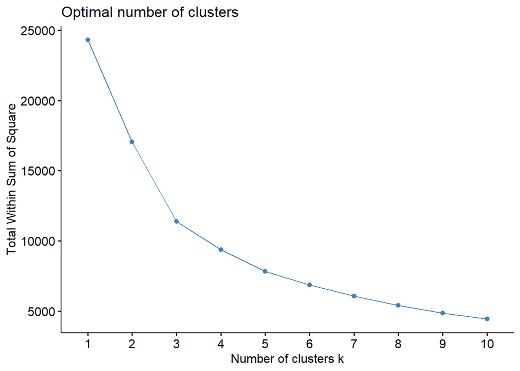

```r
fviz_nbclust(scaled_pcs, kmeans, method = "wss")
```

Maybe 3 or 4 clusters using k means as that is where the elbow is

## k = 4 clusters

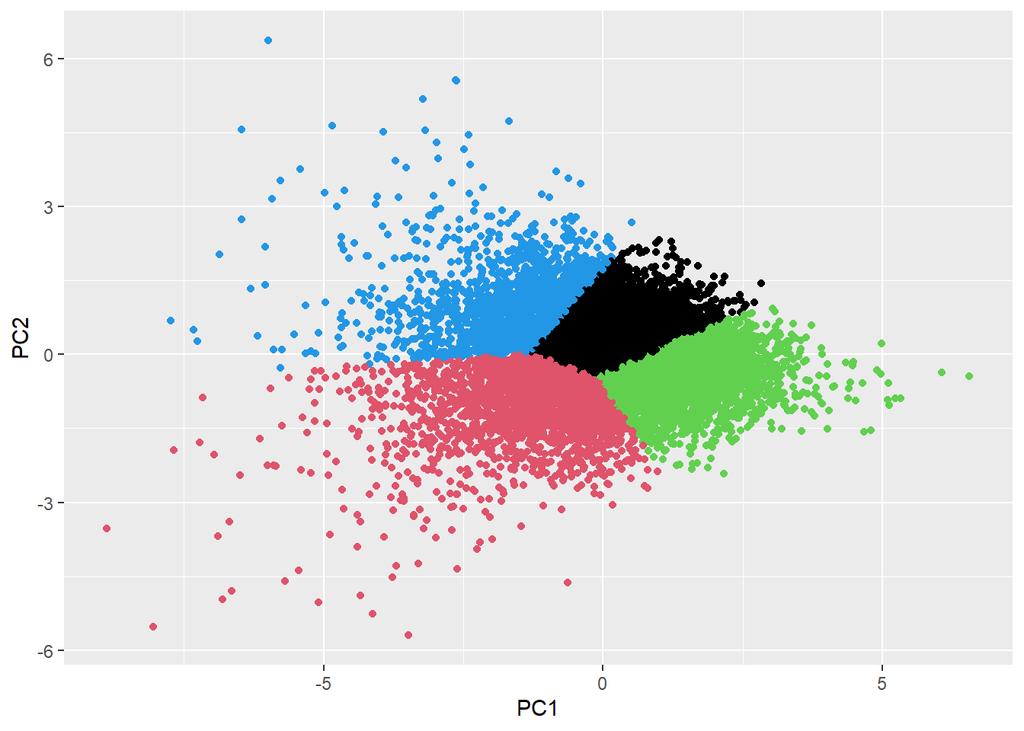

```r
set.seed(2000)
# kmeans on pc1 and pc2
k4 <- kmeans(scaled_pcs, 4, nstart=5)
k4means_cluster = k4$cluster

pcs_k4means = as.data.frame(cbind(pcs, k4means_cluster))
pcs_k4means$k4means_cluster = factor(pcs_k4means$k4means_cluster)

ggplot(pcs_k4means, aes(x = PC1, y = PC2)) +
  geom_point(color = k4means_cluster)
```

## k = 3 clusters

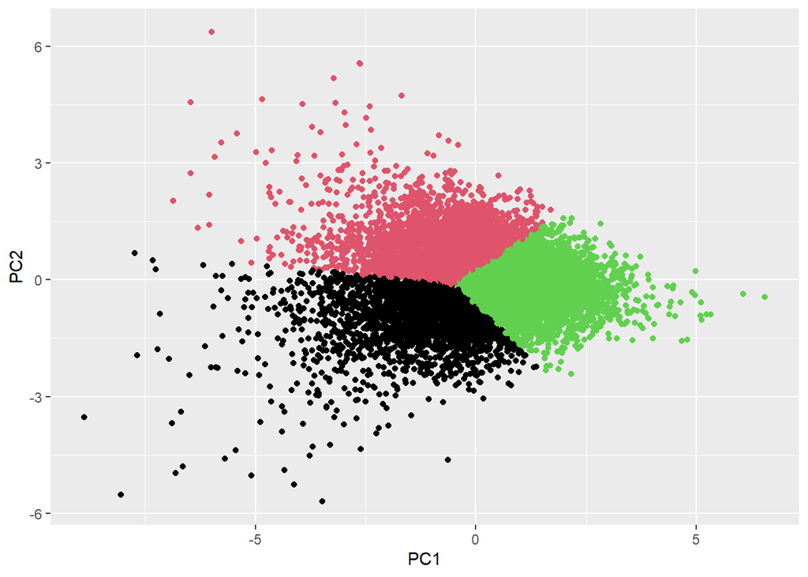

```r
# kmeans on pc1 and pc2
set.seed(2000)
k3 <- kmeans(scaled_pcs, 3, nstart=5)
k3means_cluster = k3$cluster

pcs_k3means = as.data.frame(cbind(pcs, k3means_cluster))
pcs_k3means$k3means_cluster = factor(pcs_k3means$k3means_cluster)

ggplot(pcs_k3means, aes(x = PC1, y = PC2)) +
  geom_point(color = k3means_cluster)
```

# hierarchical clustering

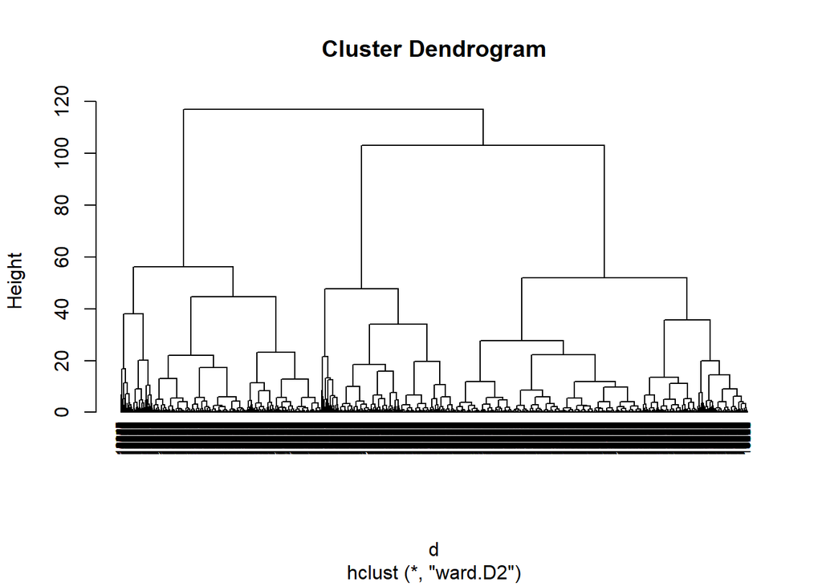

```r
# hclust on pc1 and pc2
d <- dist(scale(pcs), method = "euclidean")
hc1 <- hclust(d, method = "ward.D2")
plot(hc1, cex = 0.6, hang = -1)
```

```r
hclust3_clust <- cutree(hc1, k = 3)
hclust4_clust <- cutree(hc1, k = 4)
```

Above is dendogram for hierarchical clustering. Looks like 3/4 clusters are the best.

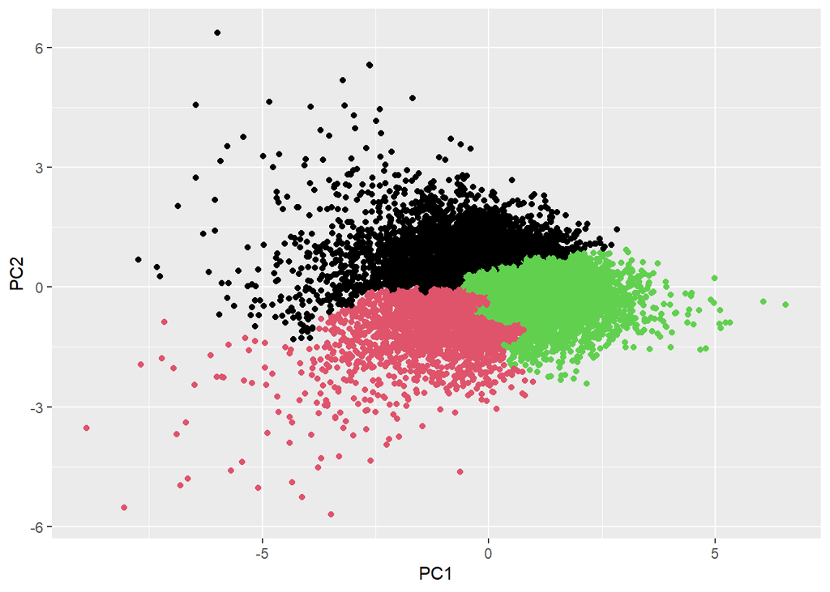

```r
pcs_hclust3 = as.data.frame(cbind(pcs, hclust3_clust))
pcs_hclust3$hclust3_clust = factor(pcs_hclust3$hclust3_clust)


ggplot(pcs_hclust3, aes(x = PC1, y = PC2)) +
  geom_point(color = hclust3_clust)
```

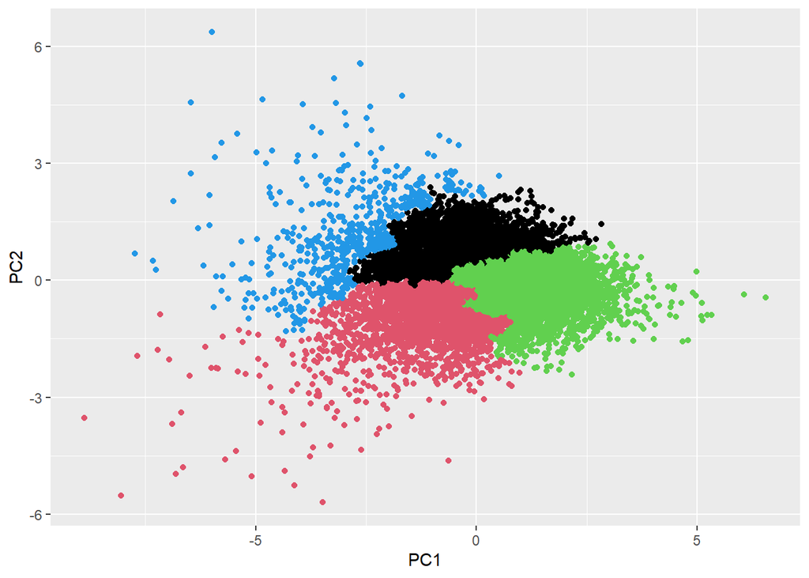

```r
pcs_hclust4 = as.data.frame(cbind(pcs, hclust4_clust))
pcs_hclust4$hclust4_clust = factor(pcs_hclust4$hclust4_clust)


ggplot(pcs_hclust4, aes(x = PC1, y = PC2)) +
  geom_point(color = hclust4_clust)
```

Hierarchical clustering gives different clusters than k means. Now to see which clustering is best/most interpretable.

```r
pct_macros_numeric = cbind(pct_macros_numeric, hclust3_clust, hclust4_clust, k3means_cluster, k4means_cluster)

pct_macros_numeric$k3means_cluster = as.factor(pct_macros_numeric$k3means_cluster)

pct_macros_numeric$k4means_cluster = as.factor(pct_macros_numeric$k4means_cluster)

pct_macros_numeric$hclust3_clust = as.factor(pct_macros_numeric$hclust3_clust)

pct_macros_numeric$hclust4_clust = as.factor(pct_macros_numeric$hclust4_clust)
```

# graphs to see which clustering method and no of clusters to pick.

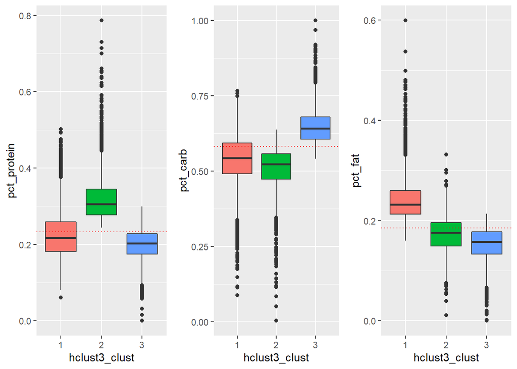

```r
hclus3_protein <- ggplot(pct_macros_numeric, aes(x = hclust3_clust, y = pct_protein)) +
  geom_boxplot(aes(fill = hclust3_clust)) +
  geom_hline(yintercept = mean(pct_macros_numeric$pct_protein),
             col = "red",
             linetype = "dotted") +
  theme(legend.position = "none")

hclus4_protein <- ggplot(pct_macros_numeric, aes(x = hclust4_clust, y = pct_protein)) +
  geom_boxplot(aes(fill = hclust4_clust)) +
  geom_hline(yintercept = mean(pct_macros_numeric$pct_protein),
             col = "red",
             linetype = "dotted") +
  theme(legend.position = "none")

k3means_protein <- ggplot(pct_macros_numeric, aes(x = k3means_cluster, y = pct_protein)) +
  geom_boxplot(aes(fill = k3means_cluster)) +
  geom_hline(yintercept = mean(pct_macros_numeric$pct_protein),
             col = "red",
             linetype = "dotted") +
  theme(legend.position = "none")

k4means_protein <- ggplot(pct_macros_numeric, aes(x = k4means_cluster, y = pct_protein)) +
  geom_boxplot(aes(fill = k4means_cluster)) +
  geom_hline(yintercept = mean(pct_macros_numeric$pct_protein),
             col = "red",
             linetype = "dotted") +
  theme(legend.position = "none")

hclus3_carb <- ggplot(pct_macros_numeric, aes(x = hclust3_clust, y = pct_carb)) +
  geom_boxplot(aes(fill = hclust3_clust)) +
  geom_hline(yintercept = mean(pct_macros_numeric$pct_carb),
             col = "red",
             linetype = "dotted") +
  theme(legend.position = "none")

hclus4_carb <- ggplot(pct_macros_numeric, aes(x = hclust4_clust, y = pct_carb)) +
  geom_boxplot(aes(fill = hclust4_clust)) +
  geom_hline(yintercept = mean(pct_macros_numeric$pct_carb),
             col = "red",
             linetype = "dotted") +
  theme(legend.position = "none")

k3means_carb <- ggplot(pct_macros_numeric, aes(x = k3means_cluster, y = pct_carb)) +
  geom_boxplot(aes(fill = k3means_cluster)) +
  geom_hline(yintercept = mean(pct_macros_numeric$pct_carb),
             col = "red",
             linetype = "dotted") +
  theme(legend.position = "none")

k4means_carb <- ggplot(pct_macros_numeric, aes(x = k4means_cluster, y = pct_carb)) +
  geom_boxplot(aes(fill = k4means_cluster)) +
  geom_hline(yintercept = mean(pct_macros_numeric$pct_carb),
             col = "red",
             linetype = "dotted") +
  theme(legend.position = "none")

hclus3_fat <- ggplot(pct_macros_numeric, aes(x = hclust3_clust, y = pct_fat)) +
  geom_boxplot(aes(fill = hclust3_clust)) +
  geom_hline(yintercept = mean(pct_macros_numeric$pct_fat),
             col = "red",
             linetype = "dotted") +
  theme(legend.position = "none")

hclus4_fat <- ggplot(pct_macros_numeric, aes(x = hclust4_clust, y = pct_fat)) +
  geom_boxplot(aes(fill = hclust4_clust)) +
  geom_hline(yintercept = mean(pct_macros_numeric$pct_fat),
             col = "red",
             linetype = "dotted") +
  theme(legend.position = "none")


k3means_fat <- ggplot(pct_macros_numeric, aes(x = k3means_cluster, y = pct_fat)) +
  geom_boxplot(aes(fill = k3means_cluster)) +
  geom_hline(yintercept = mean(pct_macros_numeric$pct_fat),
             col = "red",
             linetype = "dotted") +
  theme(legend.position = "none")

k4means_fat <- ggplot(pct_macros_numeric, aes(x = k4means_cluster, y = pct_fat)) +
  geom_boxplot(aes(fill = k4means_cluster)) +
  geom_hline(yintercept = mean(pct_macros_numeric$pct_fat),
             col = "red",
             linetype = "dotted") +
  theme(legend.position = "none")

grid.arrange(hclus3_protein, hclus3_carb, hclus3_fat, nrow = 1)
```

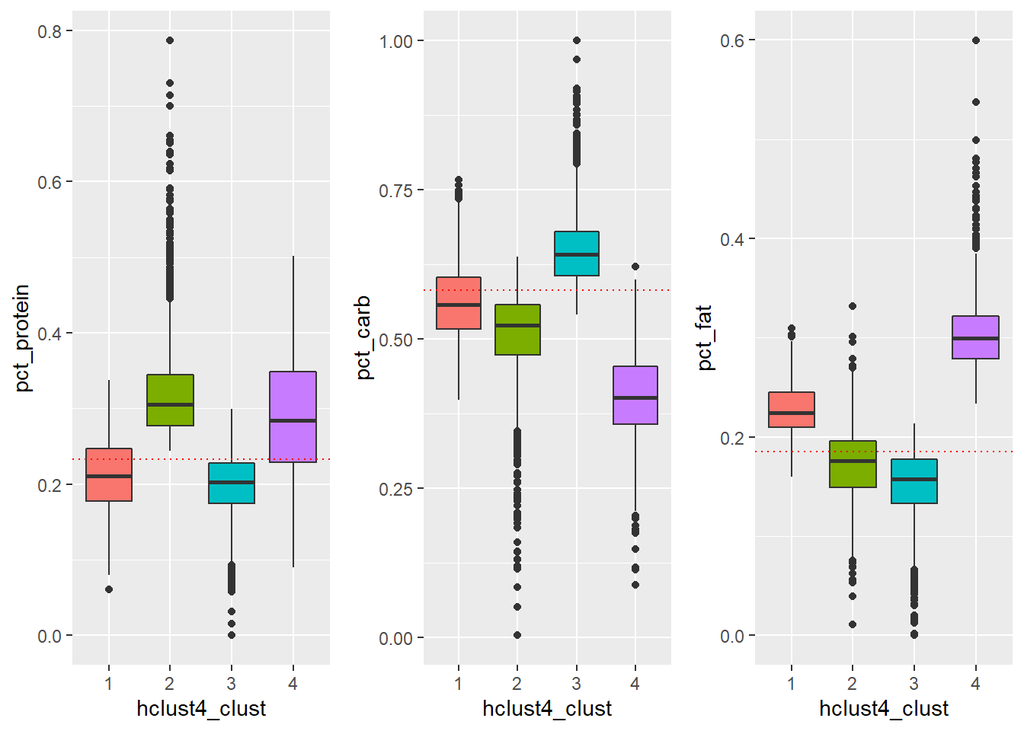

```r
grid.arrange(hclus4_protein, hclus4_carb, hclus4_fat, nrow = 1)
```

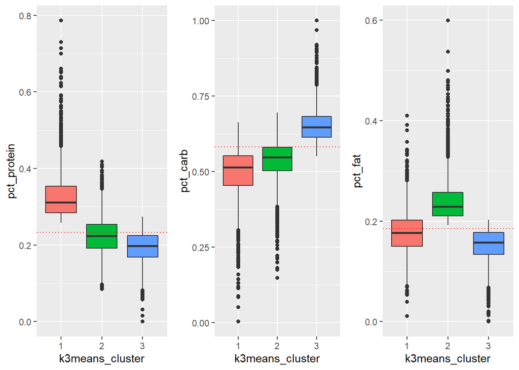

```r
grid.arrange(k3means_protein, k3means_carb, k3means_fat, nrow = 1)
```

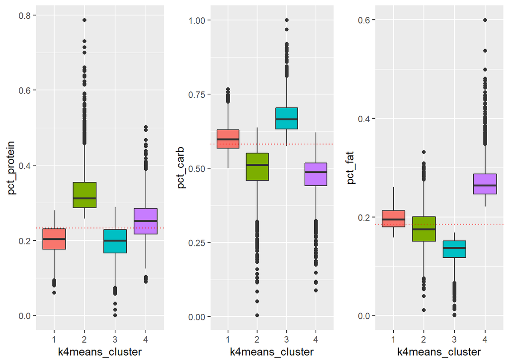

```r
grid.arrange(k4means_protein, k4means_carb, k4means_fat, nrow = 1)
```

```r
table(pct_macros_numeric$hclust4_clust)
```

```
##
##    1    2    3    4
## 3275 2601 5662  612
```

```r
table(pct_macros_numeric$k4means_clust)
```

```
##
##    1    2    3    4
## 4669 2442 3378 1661
```

Above figures show how percentage carbs/fat/protein is varied across each cluster. Red dotted line is the average for that macronutrient.

kmeans with k = 4 clustering has more interpretable results.

- Cluster 1: Normal people (average carbs, fats, proteins)
- Cluster 2: high protein low carb avg fat (maybe body builders)
- Cluster 3: avg protein, high carb, low fat
- Cluster 4: avg protein, low carb, high dat

```r
overall_means <- c("overall means",
                   mean(pct_macros_numeric$pct_fat) %>% round(3),
                   mean(pct_macros_numeric$pct_protein)%>% round(3),
                   mean(pct_macros_numeric$pct_carb)%>% round(3))

tab1 <- pct_macros_numeric %>%
  group_by(k4means_cluster) %>%
  summarise(fat = mean(pct_fat) %>% round(3),
                  protein = mean(pct_protein) %>% round(3),
                  carb = mean(pct_carb) %>% round(3))

tab1$k4means_cluster = as.character(tab1$k4means_cluster)

rbind(tab1, overall_means) %>% kable()
```

| k4means_cluster | fat | protein | carb |
| --- | --- | --- | --- |
| 1 | 0.197 | 0.202 | 0.601 |
| 2 | 0.175 | 0.329 | 0.496 |
| 3 | 0.132 | 0.196 | 0.672 |
| 4 | 0.274 | 0.253 | 0.473 |
| overall means | 0.185 | 0.233 | 0.582 |

Above is summary table for kmeans k = 4 clustering

```r
tab2 <- pct_macros_numeric %>%
  group_by(hclust4_clust) %>%
  summarise(fat = mean(pct_fat) %>% round(3),
                  protein = mean(pct_protein) %>% round(3),
                  carb = mean(pct_carb) %>% round(3))


tab2$hclust4_clust = as.character(tab2$hclust4_clust)

rbind(tab2, overall_means) %>%
  kable()
```

| hclust4_clust | fat | protein | carb |
| --- | --- | --- | --- |
| 1 | 0.228 | 0.212 | 0.56 |
| 2 | 0.172 | 0.32 | 0.508 |
| 3 | 0.153 | 0.2 | 0.647 |
| 4 | 0.309 | 0.288 | 0.403 |
| overall means | 0.185 | 0.233 | 0.582 |

# merging clusters data with biomedical data

```r
clusters = pct_macros_numeric %>% select(ABSPID,
                                         hclust4_clust,
                                         k4means_cluster)


biom_with_clusters <- merge(tech_biom, clusters, by = "ABSPID")
biom_with_clusters <- biom_with_clusters %>% select(-c(55:94))
biom_with_clusters$k4means_cluster = factor(as.character(biom_with_clusters$k4means_cluster))
biom_with_clusters$hclust4_clust = factor(as.character(biom_with_clusters$hclust4_clust))


#save(biom_with_clusters, file = "biom_with_clusters.Rdata")
```